```julia
# Running this cell for the fist time may take a while
# Packages will be precompiled
using Turing
import ForwardDiff
import PyPlot
using PyCall

plt = pyimport("matplotlib.pyplot");
plt_image = pyimport("matplotlib.image");
plt_box = pyimport("matplotlib.offsetbox");
plt_cm = pyimport("matplotlib.cm");
np = pyimport("numpy");

include("utils.jl");
```

# The Power of Probabilistic Programming

## Scenario:

1. **We have existing physics simulation.**
2. **We have some unknown parameters of the simulation.**
3. **We want to use Bayesian statistics to infer those unknowns.**

## The Environment:

A golf course which has

- a player position
- a target hole position
- a pond position

```julia
struct GolfCourse
    player_x::Float64
    hole_x::Float64
    pond_x::Float64
    function GolfCourse(;player_x::Float64, hole_x::Float64, pond_x::Float64)
        return new(player_x, hole_x, pond_x)
    end
end

pond_x0(course::GolfCourse) = course.pond_x - 0.95
pond_x1(course::GolfCourse) = course.pond_x + 0.9 #+ 0.7

function inpond(course::GolfCourse, x)
    return pond_x0(course) < x && x < pond_x1(course)
end;
```

## The simulation:

Simple classical mechanics simulation with

- initial velocity = `strike`
- acceleration = `[drag + wind, gravity]`, where `drag = -0.1` and `gravity = -1`

```julia
function get_trajectory(golf_course::GolfCourse, start::Vector{Float64}, strike::Vector{Float}, wind::Float, dt::Float64=0.1) where Float <: Floats
    position = start
    trajectory::Vector{Vector{Float}} = Vector{Float}[position]
    gravity = -1.
    drag = -0.1
    acceleration = Float[wind, gravity]
    velocity = strike
    end_x_position = 0.
    bounce = 0
    n_bounce = 2

    for i in 1:150 # upper bound on iterations
        acceleration[1] = wind + drag * sign(velocity[1])
        velocity = velocity + dt * acceleration
        position = position + dt * velocity
        if position[2] < 0.0
            # compute intersection with x-axis
            p = position
            q = trajectory[end]
            k = (q[1] - p[1]) / (q[2] - p[2])
            inter_section_x = p[1] - k * p[2]

            if bounce < n_bounce && !inpond(golf_course, inter_section_x)
                # if ball is not in pond, bounce
                position[2] = -position[2]
                velocity[1] = velocity[1] / 2.
                velocity[2] = -velocity[2] / 2.
                bounce += 1
            else
                # if ball is in pond or has bounced 3 times stop
                end_x_position = inter_section_x
                position[1] = inter_section_x
                position[2] = 0.0
            end
        end
        push!(trajectory, position)

        if position[2] == 0.
            break
        end
    end

    if position[2] != 0.
        _strike = ForwardDiff.value(strike)
        _wind = ForwardDiff.value(wind)
        _end_x_position = ForwardDiff.value(position[2])
        @warn "Simulation did not finish" _strike _wind _end_x_position
    end

    return trajectory, end_x_position
end;
```

Helper function which transforms `angle` and `power` to initial velocity vector.

```julia
function get_strike(angle::Float, power::Float) where Float <: Floats
    # angle in [0,pi/2]
    # power in [0.25,1.]
    r = (power - 0.5) * 2 # in [-0.5,1.]
    p = r + 2.75
    return [cos(angle) * p, sin(angle) * p]
end
```

```
get_strike (generic function with 1 method)
```

[figure not shown]

```julia
course = GolfCourse(player_x=0., hole_x=8., pond_x=5.5)
fig, ax = plot_golfcourse(course)
trajectory, end_x_position = get_trajectory(course, [0.,0.], get_strike(deg2rad(30),0.6), 0.)
#trajectory, end_x_position = get_trajectory(course, [0.,0.], get_strike(deg2rad(65),0.6), 0.)
#trajectory, end_x_position = get_trajectory(course, [0.,0.], get_strike(deg2rad(60),0.9), 0.)
#trajectory, end_x_position = get_trajectory(course, [0.,0.], get_strike(deg2rad(60),0.9), -0.1)
trajectory = hcat(trajectory...)
ax.scatter(trajectory[1,:], trajectory[2,:]);
# ax.vlines([pond_x0(course),pond_x1(course)],-1,1)
```

## Modelling the unknowns:

- Golfer has `goal_angle` and `goal_power`
- But depending on his `skill_level` he may deviate from the desired strike.
- This is expressed by Normal distribution with deviations depending on the `skill_level`:

```
angle ~ Normal(goal_angle, angle_deviation)
power ~ Normal(goal_power, power_deviation)
```

```julia
struct Golfer
    skill_level::Int # (1,2,3)
    function Golfer(;skill_level::Int)
        return new(skill_level)
    end
end

@model function strike(golfer::Golfer, goal_angle::Float, goal_power::Float) where Float <: Floats
    @assert golfer.skill_level in (1,2,3)

    if golfer.skill_level == 1
        angle_deviation = 0.05
        power_deviation = 0.05
    elseif golfer.skill_level == 2
        angle_deviation = 0.0125
        power_deviation = 0.0125
    elseif golfer.skill_level == 3
        angle_deviation = 0.00625
        power_deviation = 0.00625
    end

    angle ~ Normal(goal_angle, angle_deviation)
    power ~ Normal(goal_power, power_deviation)

    return get_strike(angle, power)
end;
```

In the `play_golf` model, we simply wrap our physics simulation.

```julia
@model function play_golf(
        course::GolfCourse,
        golfer::Golfer;
        goal_angle=missing,
        goal_power=missing,
        end_position=missing,
        inverse_problem=false
    )

    goal_angle ~ Uniform(deg2rad(5), deg2rad(85))
    goal_power ~ Uniform(0.25, 1.0)

    @submodel golfer_strike = strike(golfer, goal_angle, goal_power)

    wind ~ Normal(0., 0.015)
    _, end_x_position = get_trajectory(course, Float64[course.player_x,0.], golfer_strike, wind)


    if inverse_problem
        # hitting the golf holf perfectly has probability 0.
        # we have to allow some margin 0.1
        end_position ~ Normal(end_x_position, 0.1)
    else
        # just for tracking the end position
        end_position ~ Dirac(end_x_position)
    end

    return end_x_position
end;
```

To get a feel for the model, we will sample from the prior distribution.

[figure not shown]

```julia
model = play_golf(course,
    Golfer(skill_level=3);        # in [1,2,3]
    goal_angle    = deg2rad(55),  # in [5,85]
    goal_power    = 0.7,          # in [0.25,1.0]
)
traces = sample(model, Prior(), 1_000);
plot_traces(course, traces);
```

## Inverting the Model:

Up until now we simply generated random golf strikes.

But we can also use probabilistic programming to infer unkown values.

In fact, we can use probabilistic programming to answer following question:

### GIVEN that we hit the golf hole, what are angle and power?

```julia
inverse_model = play_golf(course,
    Golfer(skill_level=3);
    end_position    = course.hole_x,
    inverse_problem = true
);
```

```julia
Turing.Random.seed!(0)
result_IS = sample(inverse_model, IS(), 500_000);
weights = exp.(normalise(vec(result_IS["lp"])));
```

```
Sampling: 100%|█████████████████████████████████████████| Time: 0:01:07
```

Visualising the results allows us to interpret the joint posterior distribution of angle and power.

That means we do not only get one solution, but an entire distribution over angle and power that works well.

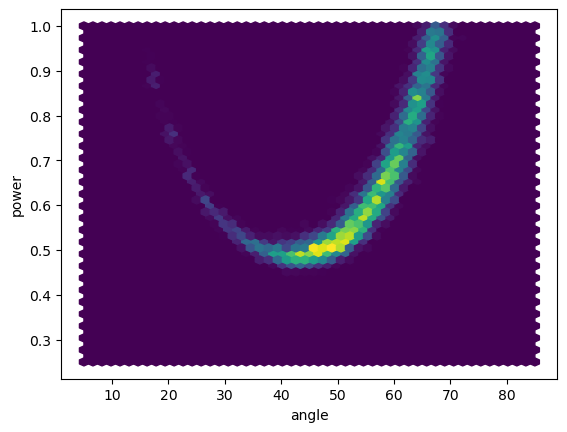

```julia
goal_angle = rad2deg.(vec(result_IS["goal_angle"]))
goal_power = vec(result_IS["goal_power"])
plt.hexbin(goal_angle, goal_power, C=weights, reduce_C_function=np.sum, gridsize=50);
plt.xlabel("angle"); plt.ylabel("power");
```

We can also visualise the trajectories that belong to these solution values.

[figure not shown]

```julia
Turing.Random.seed!(0)
ixs = rand(Categorical(weights),1000)
plot_traces(course, result_IS[ixs]);
```

Maybe it is also interesting to see, which are the angle and power values that are the most likely to hit the goal.

```julia
# Estimates the MAP by finding the highest weighted bin of the posterior histogram.
counts, x, y = np.histogram2d(goal_angle, goal_power, weights=weights, bins=100)
i, j = Tuple(argmax(counts))
map_angle = 0.5 * (x[i+1] + x[i])
map_power = 0.5 * (y[j+1] + y[j])
map_angle, map_power
```

```
(58.19986132989064, 0.6512491669363114)
```

```
Sampling: 100%|█████████████████████████████████████████| Time: 0:00:00
```

[figure not shown]

```julia
Turing.Random.seed!(0)
model = play_golf(course,
    Golfer(skill_level=3);
    goal_angle    = deg2rad(map_angle),
    goal_power    = map_power,
)
traces_1 = sample(model, Prior(), 10000)
plot_traces(course, traces_1[1:1000]);
```

Results look fine so far, but we always assume that we have professional golfer with `skill_level = 3`.

### What happens if we let a less experienced golfer give it a shot?

```
Sampling: 100%|█████████████████████████████████████████| Time: 0:00:00
```

[figure not shown]

```julia
Turing.Random.seed!(0)
model = play_golf(course,
    Golfer(skill_level=1);
    goal_angle    = deg2rad(map_angle),
    goal_power    = map_power,
)
traces_3 = sample(model, Prior(), 10000)
plot_traces(course, traces_3[1:1000]);
```

#### What is the probability of hitting the pond?

```julia
mean(map(x -> inpond(course, x), vec(traces_3[:end_position])))
```

```
0.2609
```

```
Sampling: 100%|█████████████████████████████████████████| Time: 0:00:00
```

[figure not shown]

```julia
Turing.Random.seed!(0)
model = play_golf(course,
    Golfer(skill_level=2);
    goal_angle    = deg2rad(map_angle),
    goal_power    = map_power
)
traces_2 = sample(model, Prior(), 10000)
plot_traces(course, traces_2[1:1000]);
```

```julia
println("Prob. of hitting pond skill_level = 3: ", mean(map(x -> inpond(course, x), vec(traces_3[:end_position]))))
println("Prob. of hitting pond skill_level = 2: ", mean(map(x -> inpond(course, x), vec(traces_2[:end_position]))))
println("Prob. of hitting pond skill_level = 1: ", mean(map(x -> inpond(course, x), vec(traces_1[:end_position]))))
```

[output not shown]

### Golfer with skill level 2, seems to be good choice, but we observe bad trajectory!?

[figure not shown]

```julia
observed_trajectory = get_observed_trajectory(course)
fig, ax = plot_golfcourse(course)
ax.plot(observed_trajectory[1,:], observed_trajectory[2,:]);
```

### GIVEN that we aim for best angle and power and GIVEN that we miss the target, what happened?

```julia
Turing.Random.seed!(0)
model = play_golf(course,
    Golfer(skill_level=2);
    goal_angle    = deg2rad(map_angle),
    goal_power    = map_power,
    end_position    = 9.,
    inverse_problem = true
)
result = sample(model, IS(), 100000);
weights = exp.(normalise(vec(result["lp"])));
```

```
Sampling: 100%|█████████████████████████████████████████| Time: 0:00:07
```

```julia
# Turing.Random.seed!(0)
# ixs = rand(Categorical(weights),1000);
# plot_traces(course, result[ixs]);
```

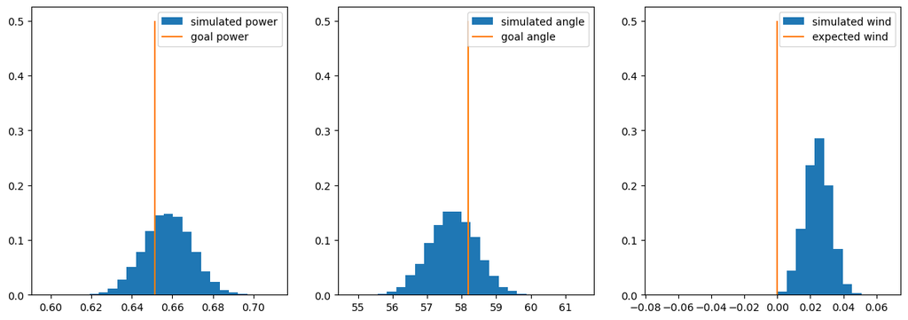

```julia
fig, axs = plt.subplots(1,3,figsize=(15,5))
axs[1].hist(vec(result["power"]), weights=weights, bins=25, label="simulated power");
axs[1].vlines([map_power], 0, 0.5, color="tab:orange", label="goal power")
axs[1].legend();
axs[2].hist(rad2deg.(vec(result["angle"])), weights=weights, bins=25, label="simulated angle");
axs[2].vlines([map_angle], 0, 0.5, color="tab:orange", label="goal angle")
axs[2].legend();
axs[3].hist(vec(result["wind"]), weights=weights, bins=25, label="simulated wind");
axs[3].vlines([0.], 0, 0.5, color="tab:orange", label="expected wind")
axs[3].legend();
```

## Gradient-Based Methods

Since the simulation is differentiable with respect to angle and power,  
we can use more sophisticated inference algorithms that leverage automatic differentiation.

```julia
vi = Turing.VarInfo(inverse_model);
keys(vi.metadata)
```

```
(:goal_angle, :goal_power, :angle, :power, :wind)
```

```julia
initial_params = [deg2rad(map_angle),map_power,deg2rad(map_angle),map_power,0.1];
```

```julia
inverse_model = play_golf(course,
    Golfer(skill_level=2);
    end_position    = course.hole_x,
    inverse_problem = true
);

Turing.Random.seed!(0)
result_HMC = sample(inverse_model, HMC(0.003,15), 100_000, initial_params=initial_params);
```

```
Sampling: 100%|█████████████████████████████████████████| Time: 0:00:44
```

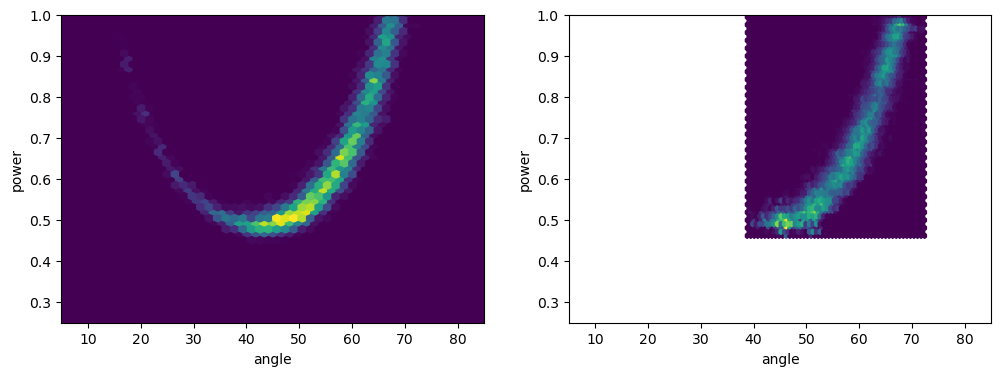

```julia
function plot_HMC_result(result_HMC)
    fig, axs = plt.subplots(1,2,figsize=(12,4))

    goal_angle_IS = rad2deg.(vec(result_IS["goal_angle"]))
    goal_power_IS = vec(result_IS["goal_power"])
    weights = exp.(normalise(vec(result_IS["lp"])));
    axs[1].hexbin(goal_angle_IS, goal_power_IS, C=weights, reduce_C_function=np.sum, gridsize=50);
    axs[1].set_xlabel("angle"); axs[1].set_ylabel("power");
    axs[1].set_ylim((0.25,1.)); axs[1].set_xlim((5, 85))

    goal_angle_HMC = rad2deg.(vec(result_HMC["goal_angle"].data))
    goal_power_HMC = vec(result_HMC["goal_power"].data);

    axs[2].hexbin(goal_angle_HMC, goal_power_HMC, gridsize=50);
    axs[2].set_ylim((0.25,1.)); axs[2].set_xlim((5, 85))
    axs[2].set_xlabel("angle"); axs[2].set_ylabel("power");
end
plot_HMC_result(result_HMC);
```

```julia
@time begin
    Turing.Random.seed!(0)
    nchains = Threads.nthreads()
    result_HMC_2 = sample(inverse_model, HMC(0.003,15), MCMCThreads(), 25_000, nchains, initial_params=[copy(initial_params) for _ in 1:nchains]);
end;
```

[output not shown]

```
 33.472964 seconds (1.66 G allocations: 212.759 GiB, 42.50% gc time, 3.32% compilation time)
```

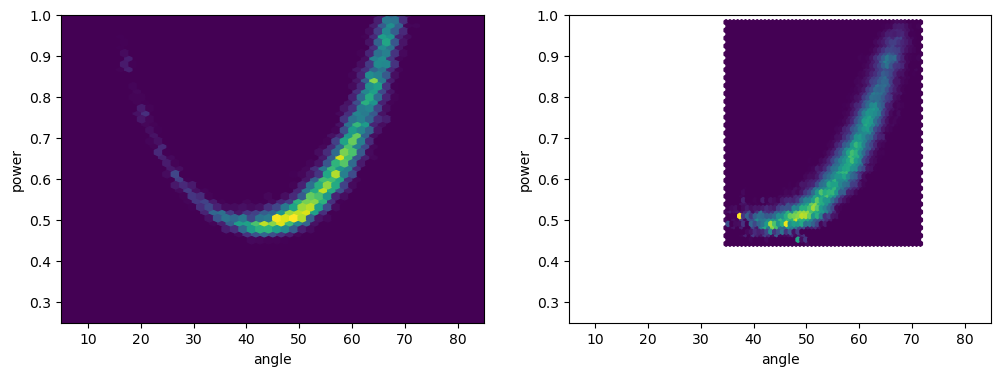

```julia
plot_HMC_result(result_HMC_2);
```